# Homework 3

Bernard Gonzales

2024-12-6

On my honor, I have neither given nor received unauthorized aid on this assignment.

```r
library(Rmpfr)
dat = read.csv("coaldisasters-ds6040.csv")


gibbs_sampler = function(iter, dat, a_mu, b_mu, a_lambda, b_lambda){

  mu_vec = vector()
  lambda_vec = vector()
  k_prob_mat = matrix(nrow = iter+1, ncol = 111)
  k_samp_vec = vector()
  #Initialize sampler
    mu_vec[1] = rgamma(1,a_mu, rate  = b_mu)
  lambda_vec[1] = rgamma(1,a_lambda, rate = b_lambda)
  k_prob_mat[1,] = rep(1/111, 111)
  k_samp_vec[1] = 56

  #Sampler
  for(i in 2:(iter+1)){
    k = k_samp_vec[i-1]
    mu_vec[i] = rgamma(1, a_mu + sum(dat$Count[1:k]), rate = k + b_mu)
    lambda_vec[i] = rgamma(1, a_lambda + sum(dat$Count[(k+1):112]), rate = 112 - k + b_lambda)

    l_temp = vector()
  for(j in 1:111){
    l_temp[j] = sum(log(mpfr(dpois(dat[1:j,2], lambda = rep(mu_vec[i],j)), precBits = 100))) + sum(log(mpfr(dpois(dat[(j+1):112,2], lambda = rep(lambda_vec[i],112-j)), precBits = 100)))
  }
  l_temp <- mpfr(l_temp, precBits = 100)
  k_prob_mat[i,] = as.numeric(exp(l_temp)/sum(exp(l_temp)))
  k_samp_vec[i] = sample(size = 1,1:111, prob = k_prob_mat[i,])
  }
  toReturn = data.frame(mu = mu_vec, lambda = lambda_vec, k = k_samp_vec)

  return(toReturn)
}

test = gibbs_sampler(1000, dat, a_mu = 1, b_mu = 1, a_lambda = 1, b_lambda = 1)

write.csv(test, 'gibbs_sampler.csv')
```

```r
library(tidyverse)
```

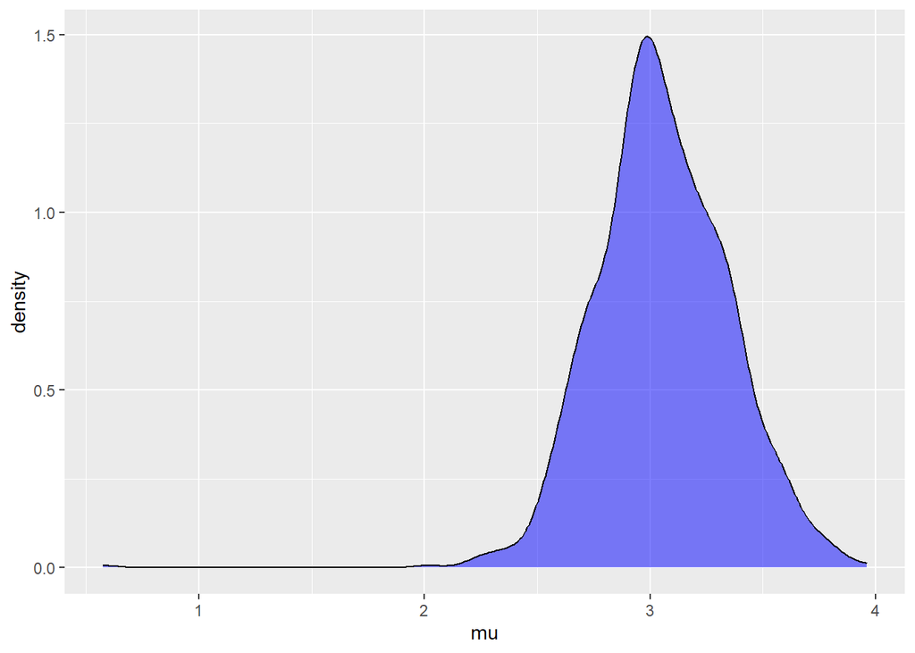

```r
test$index <- 1:1001
ggplot(test, aes(mu)) +
  geom_density(fill = 'blue', alpha = 0.5)
```

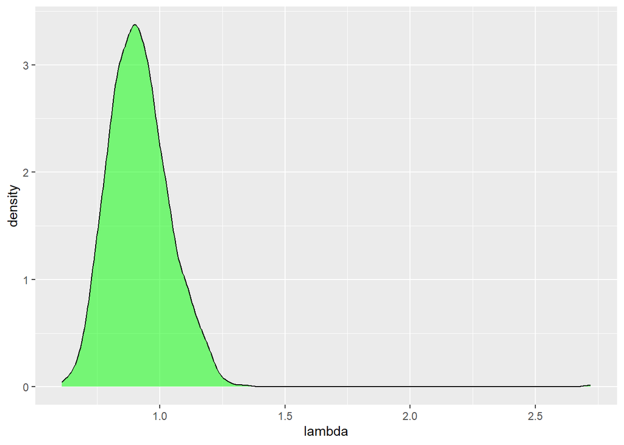

```r
ggplot(test, aes(lambda)) +
  geom_density(fill = 'green', alpha = 0.5)
```

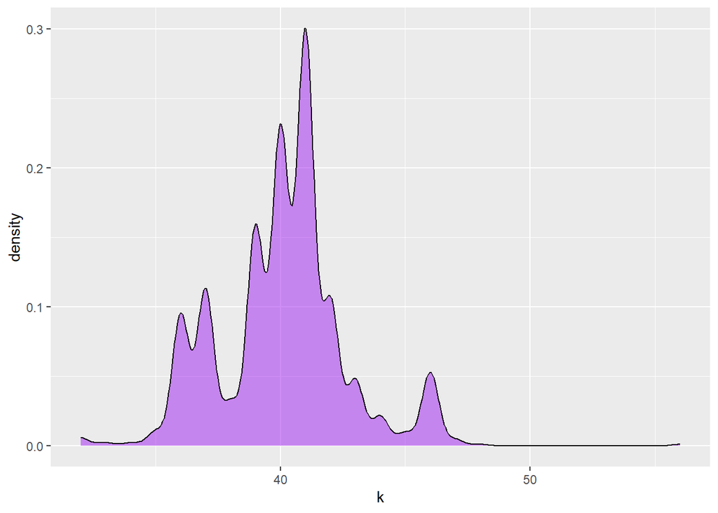

```r
ggplot(test, aes(k)) +
  geom_density(fill = 'purple', alpha = 0.5)
```

```r
mu_mean <- mean(test$mu)
mu_ci <- quantile(test$mu, probs = c(0.025, 0.975))

lambda_mean <- mean(test$lambda)
lambda_ci <- quantile(test$lambda, probs = c(0.025, 0.975))

cat("EAP Estimate and 95% Credible Interval for μ:\n")
```

```
## EAP Estimate and 95% Credible Interval for μ:
```

```r
cat("EAP Estimate:", mu_mean, "\n")
```

```
## EAP Estimate: 3.054667
```

```r
cat("95% CI:", mu_ci, "\n\n")
```

```
## 95% CI: 2.533394 3.631543
```

```r
cat("EAP Estimate and 95% Credible Interval for λ:\n")
```

```
## EAP Estimate and 95% Credible Interval for λ:
```

```r
cat("EAP Estimate:", lambda_mean, "\n")
```

```
## EAP Estimate: 0.9188432
```

```r
cat("95% CI:", lambda_ci, "\n")
```

```
## 95% CI: 0.715956 1.166011
```

A credible interval might not be the most appropriate if we know that the changepoint was instantaneous or discrete. The EAP is more applicable to continuous probability distributions. Because we are looking for a changepoint in the rate of coal mining disasters using Poisson distributions for our model, we would probably use the **maximum a posteriori (MAP)**, which would represent the most likely single value, since Poisson distributions (and our data on the coal mining disasters) are discrete.

```r
met_in_gibbs_sampler = function(iter, dat, a_mu, b_mu, a_lambda, b_lambda){

  mu_vec = vector()
  lambda_vec = vector()
  k_prob_mat = matrix(nrow = iter+1, ncol = 111)
  k_samp_vec = vector()
  #Initialize sampler
    mu_vec[1] = rgamma(1,a_mu, rate  = b_mu)
  lambda_vec[1] = rgamma(1,a_lambda, rate = b_lambda)
  k_prob_mat[1,] = rep(1/111, 111)
  k_samp_vec[1] = 56

  #Sampler
  for (i in 2:(iter + 1)) {
    # Current value of k
    current_k <- k_samp_vec[i - 1]

    # Update mu and lambda based on current k
    mu_vec[i] <- rgamma(1, a_mu + sum(dat$Count[1:current_k]), rate = current_k + b_mu)
    lambda_vec[i] <- rgamma(1, a_lambda + sum(dat$Count[(current_k + 1):112]), rate = 112 - current_k + b_lambda)

    # Metropolis step for k
    # Propose a new k* uniformly from 1 to 112
    proposed_k <- sample(1:112, size = 1)

    # Calculate log likelihood ratio for the acceptance ratio a_k
    log_likelihood_current_k <- sum(dpois(dat$Count[1:current_k], lambda = mu_vec[i], log = TRUE)) + sum(dpois(dat$Count[(current_k + 1):112], lambda = lambda_vec[i], log = TRUE))

    log_likelihood_proposed_k <- sum(dpois(dat$Count[1:proposed_k], lambda = mu_vec[i], log = TRUE)) + sum(dpois(dat$Count[(proposed_k + 1):112], lambda = lambda_vec[i], log = TRUE))

    # Compute acceptance probability a_k
    a_k <- exp(log_likelihood_proposed_k - log_likelihood_current_k)

    # Check for NA or NaN in a_k and set to 0 if necessary
    if (is.na(a_k) || is.nan(a_k)) {
      a_k <- 0  # Setting a_k to 0 means we will always reject k* if a_k is undefined
    }

    # Sample r from Uniform(0, 1)
    r <- runif(1)

    # Accept or reject proposed k*
    if (r < a_k) {
      k_samp_vec[i] <- proposed_k
    } else {
      k_samp_vec[i] <- current_k
    }
  }
  toReturn = data.frame(mu = mu_vec, lambda = lambda_vec, k = k_samp_vec)

  return(toReturn)
}

sec = met_in_gibbs_sampler(1000, dat, a_mu = 1, b_mu = 1, a_lambda = 1, b_lambda = 1)
```

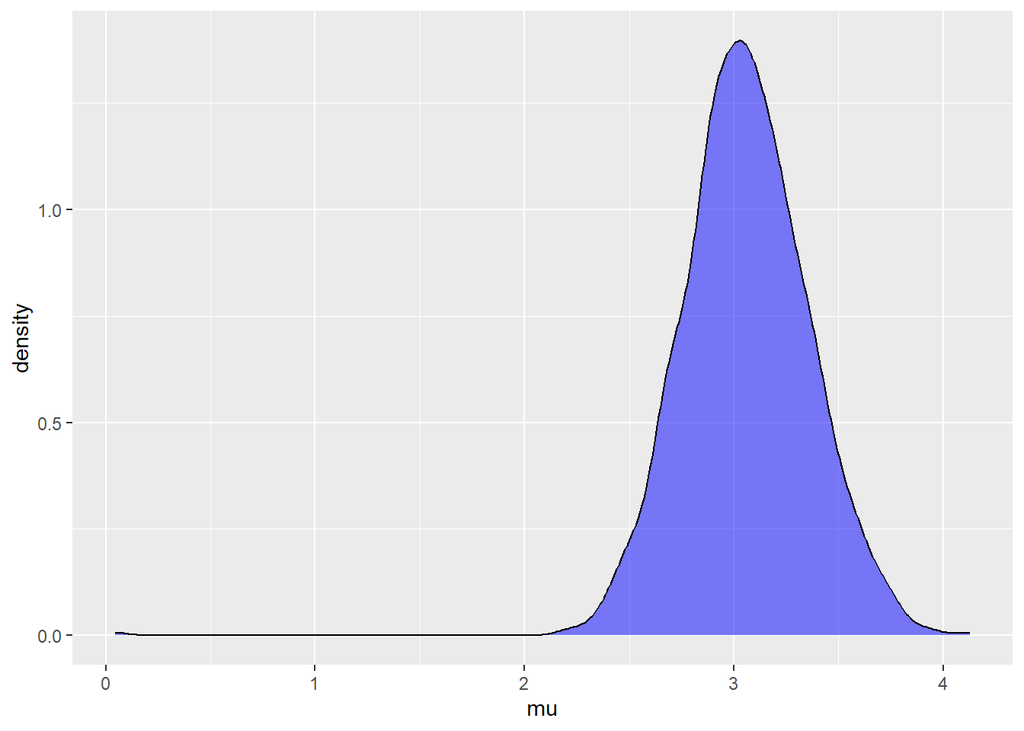

```r
sec$index <- 1:1001
ggplot(sec, aes(mu)) +
  geom_density(fill = 'blue', alpha = 0.5)
```

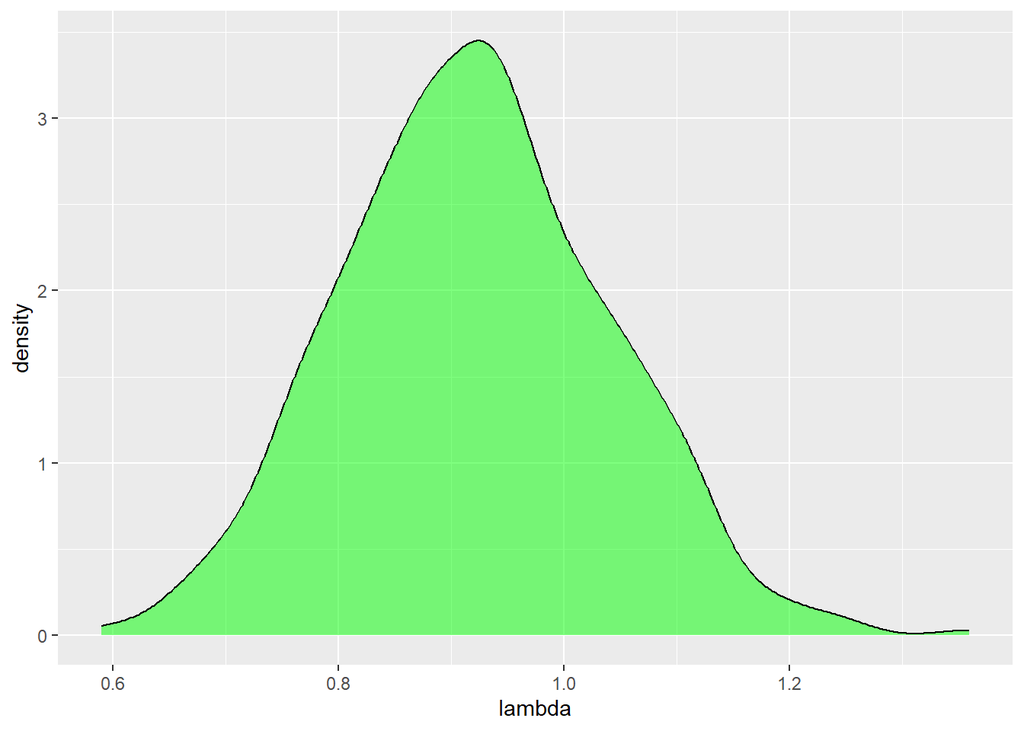

```r
ggplot(sec, aes(lambda)) +
  geom_density(fill = 'green', alpha = 0.5)
```

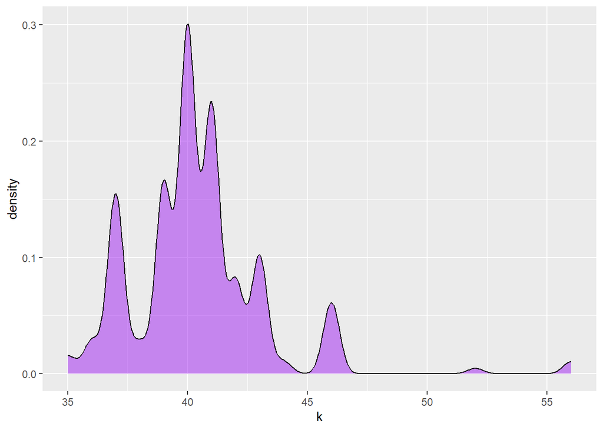

```r
ggplot(sec, aes(k)) +
  geom_density(fill = 'purple', alpha = 0.5)
```

```r
cat("EAP Estimate and 95% Credible Interval for μ:\n")
```

```
## EAP Estimate and 95% Credible Interval for μ:
```

```r
cat("EAP Estimate:", mean(sec$mu), "\n")
```

```
## EAP Estimate: 3.05606
```

```r
cat("95% CI:", quantile(sec$mu, probs = c(0.025, 0.975)), "\n\n")
```

```
## 95% CI: 2.495343 3.631064
```

```r
cat("EAP Estimate and 95% Credible Interval for λ:\n")
```

```
## EAP Estimate and 95% Credible Interval for λ:
```

```r
cat("EAP Estimate:", mean(sec$lambda), "\n")
```

```
## EAP Estimate: 0.9207528
```

```r
cat("95% CI:", quantile(sec$lambda, probs = c(0.025, 0.975)), "\n")
```

```
## 95% CI: 0.6945804 1.143105
```

The results are very similar, since the EAPs and the 95% credible intervals are almost identical. (I don’t know why the scaling for the x-axis on the density of lambda values is different.)

The issue with this implementation is that if the difference in the log-likelihoods is too large or too small, $a_k$ could be `Inf` or so small that the result would come out too small. This is because exponentiating the difference in log-likelihoods carries the risk of underflow. A better solution would be comparing the logarithmic results instead ($log(a_k)$ & $log(r)$ instead of $a_k$ & $r$).

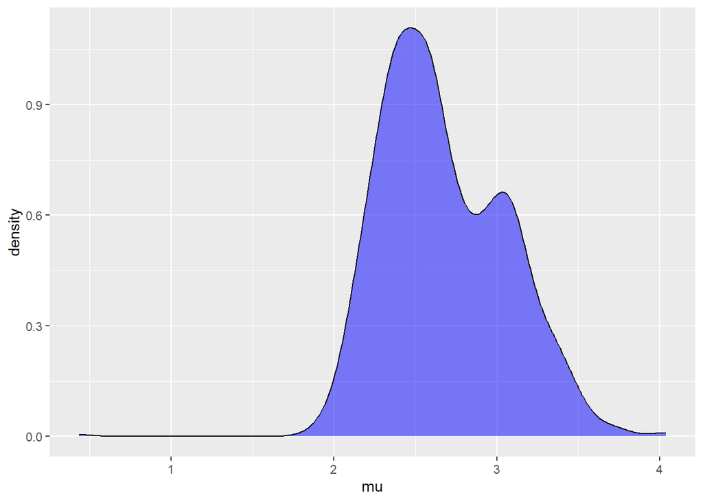

```r
mod_met_in_gibbs_sampler = function(iter, dat, a_mu, b_mu, a_lambda, b_lambda){

  mu_vec = vector()
  lambda_vec = vector()
  k_prob_mat = matrix(nrow = iter+1, ncol = 111)
  k_samp_vec = vector()
  #Initialize sampler
    mu_vec[1] = rgamma(1,a_mu, rate  = b_mu)
  lambda_vec[1] = rgamma(1,a_lambda, rate = b_lambda)
  k_prob_mat[1,] = rep(1/111, 111)
  k_samp_vec[1] = 56

  #Sampler
  for (i in 2:(iter + 1)) {
    # Current value of k
    current_k <- k_samp_vec[i - 1]

    # Update mu and lambda based on current k
    mu_vec[i] <- rgamma(1, a_mu + sum(dat$Count[1:current_k]), rate = current_k + b_mu)
    lambda_vec[i] <- rgamma(1, a_lambda + sum(dat$Count[(current_k + 1):112]), rate = 112 - current_k + b_lambda)

    # Metropolis step for k
    # Propose a new k* uniformly from 1 to 112
    proposed_k <- sample((current_k - 1):(current_k + 1), size = 1)

    # Calculate log likelihood ratio for the acceptance ratio a_k
    log_likelihood_current_k <- sum(dpois(dat$Count[1:current_k], lambda = mu_vec[i], log = TRUE)) + sum(dpois(dat$Count[(current_k + 1):112], lambda = lambda_vec[i], log = TRUE))

    log_likelihood_proposed_k <- sum(dpois(dat$Count[1:proposed_k], lambda = mu_vec[i], log = TRUE)) + sum(dpois(dat$Count[(proposed_k + 1):112], lambda = lambda_vec[i], log = TRUE))

    # Compute acceptance probability a_k
    a_k <- exp(log_likelihood_proposed_k - log_likelihood_current_k)

    # Check for NA or NaN in a_k and set to 0 if necessary
    if (is.na(a_k) || is.nan(a_k)) {
      a_k <- 0  # Setting a_k to 0 means we will always reject k* if a_k is undefined
    }

    # Sample r from Uniform(0, 1)
    r <- runif(1)

    # Accept or reject proposed k*
    if (r < a_k) {
      k_samp_vec[i] <- proposed_k
    } else {
      k_samp_vec[i] <- current_k
    }
  }
  toReturn = data.frame(mu = mu_vec, lambda = lambda_vec, k = k_samp_vec)

  return(toReturn)
}

third = mod_met_in_gibbs_sampler(1000, dat, a_mu = 1, b_mu = 1, a_lambda = 1, b_lambda = 1)
third$index = 1:1001
ggplot(third, aes(mu)) +
  geom_density(fill = 'blue', alpha = 0.5)
```

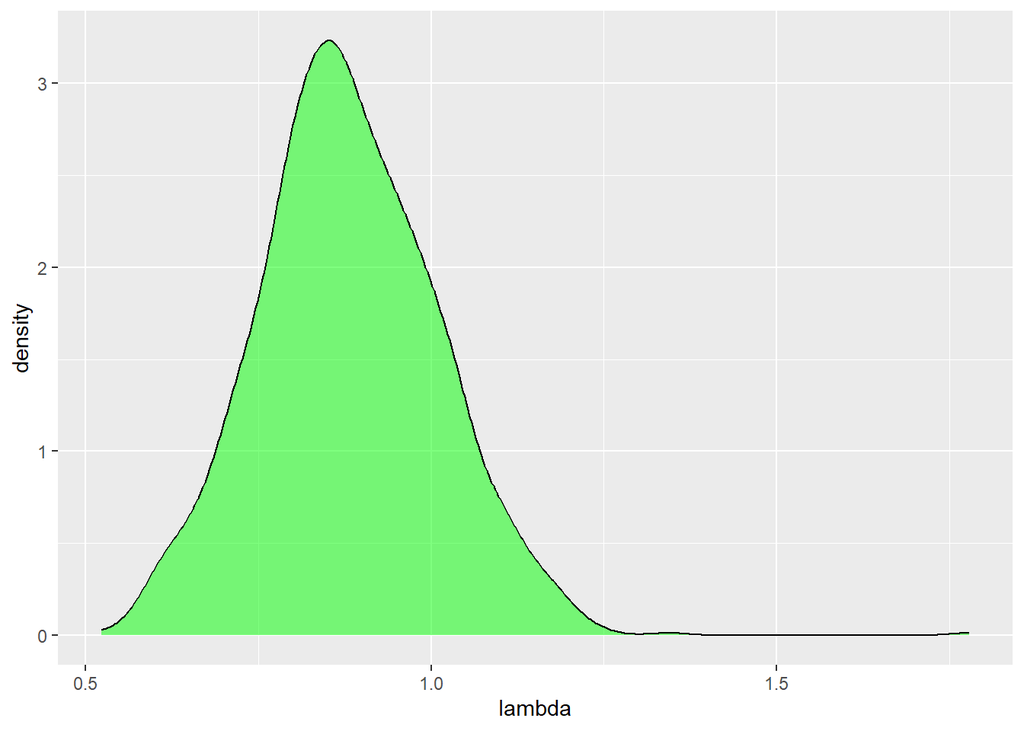

```r
ggplot(third, aes(lambda)) +
  geom_density(fill = 'green', alpha = 0.5)
```

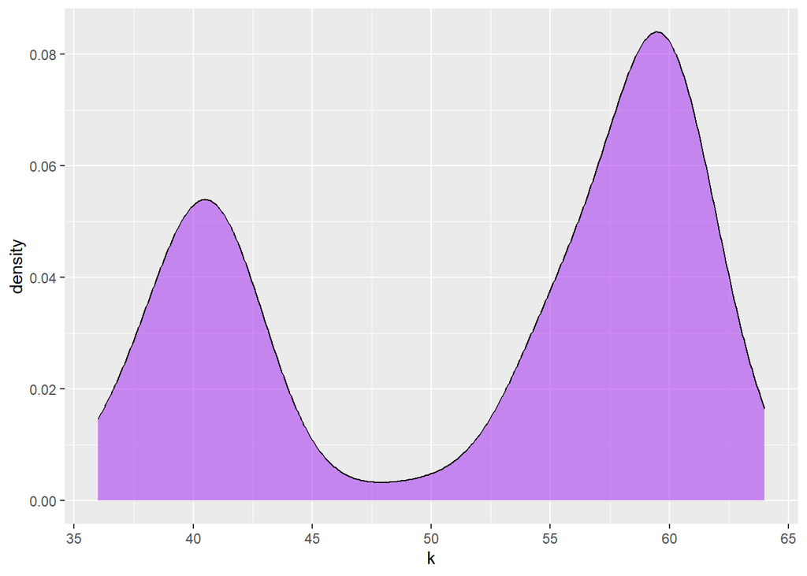

```r
ggplot(third, aes(k)) +
  geom_density(fill = 'purple', alpha = 0.5)
```

```r
library(brms)
wine <- read.csv('whitewine-training-ds6040.csv')
wine$a <- ifelse(wine$wine_quality == 'A', 1, 0)

just_a <- subset(wine, a == 1)

wines <- brm(formula = a ~ residual.sugar + chlorides + sulphates, family = bernoulli(), data = wine, chains = 4, iter = 1000, seed = 123)
a_wines <- brm(formula = a ~ residual.sugar + chlorides + sulphates, family = bernoulli(), data = just_a, chains = 4, iter = 1000, seed = 123)
print(wines)
```

```
##  Family: bernoulli
##   Links: mu = logit
## Formula: a ~ residual.sugar + chlorides + sulphates
##    Data: wine (Number of observations: 3178)
##   Draws: 4 chains, each with iter = 1000; warmup = 500; thin = 1;
##          total post-warmup draws = 2000
##
## Regression Coefficients:
##                Estimate Est.Error l-95% CI u-95% CI Rhat Bulk_ESS Tail_ESS
## Intercept         -3.67      0.13    -3.94    -3.42 1.00     1716     1451
## residual.sugar    -0.03      0.12    -0.27     0.20 1.00     1205     1130
## chlorides         -1.05      0.24    -1.54    -0.59 1.00     1380     1422
## sulphates          0.02      0.10    -0.17     0.22 1.00     1615     1332
##
## Draws were sampled using sampling(NUTS). For each parameter, Bulk_ESS
## and Tail_ESS are effective sample size measures, and Rhat is the potential
## scale reduction factor on split chains (at convergence, Rhat = 1).
```

```r
print(a_wines)
```

```
##  Family: bernoulli
##   Links: mu = logit
## Formula: a ~ residual.sugar + chlorides + sulphates
##    Data: just_a (Number of observations: 100)
##   Draws: 4 chains, each with iter = 1000; warmup = 500; thin = 1;
##          total post-warmup draws = 2000
##
## Regression Coefficients:
##                Estimate Est.Error l-95% CI u-95% CI Rhat Bulk_ESS Tail_ESS
## Intercept       7522.76  12649.13    38.54 45619.01 2.17        5       14
## residual.sugar  -582.89   3021.44 -9573.45  2235.94 1.44       37       11
## chlorides       2281.71   5069.39 -1739.82 18585.71 1.42       10       13
## sulphates        117.97   1653.03 -3533.29  4471.49 1.51       51       27
##
## Draws were sampled using sampling(NUTS). For each parameter, Bulk_ESS
## and Tail_ESS are effective sample size measures, and Rhat is the potential
## scale reduction factor on split chains (at convergence, Rhat = 1).
```

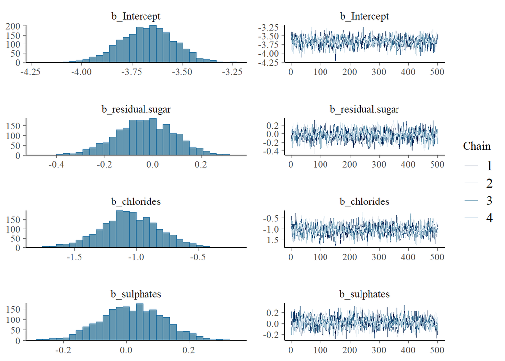

```r
plot(wines)
```

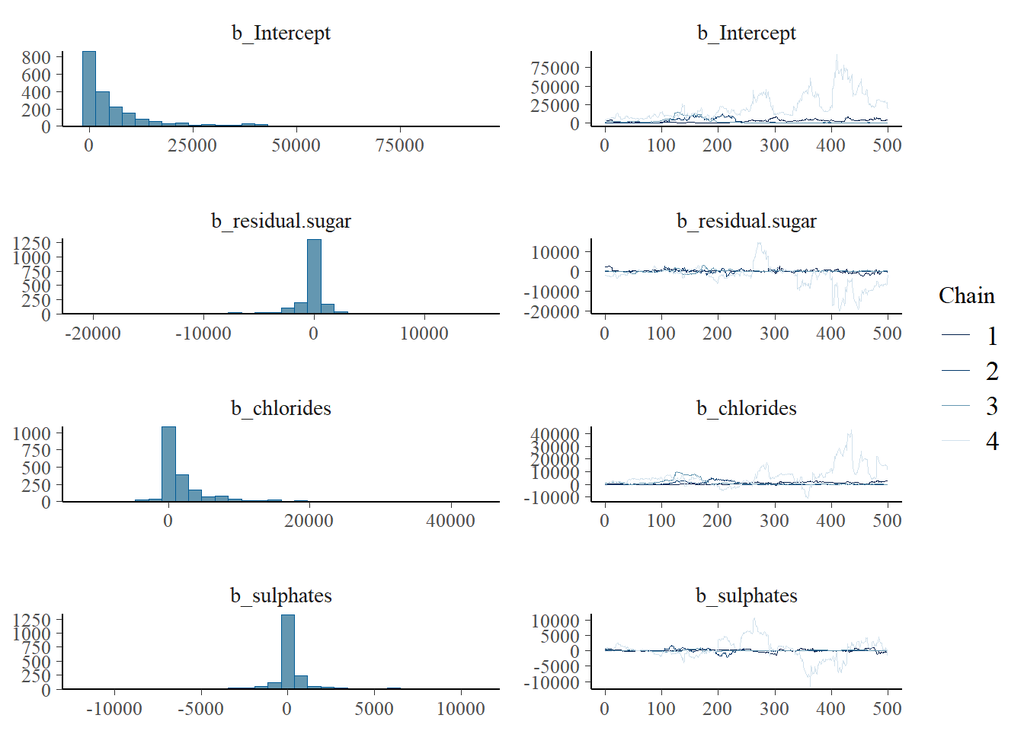

```r
plot(a_wines)
```

Based on the traceplots from the two logistic models, the first model’s intercept and coefficients converge, while the second mode’s intercept and coefficients do not converge, and tend to wander randomly. Thus, the first model, which used all of the wines, would be better at classifying the wines than the second model. This makes sense because the second model only used the wines that received an `A`, so it was not able to make generalizations about other wines which did not receive an `A`.